# ggplot faceting tutorial

Vlad Tarko

# 1 Overview

“Faceting” is `ggplot`’s ability to produce many different plots with a single command. I’m going to illustrate it here by producing multiple scatter plots, but you can facet any kind of plot.

There are four types of faceting:

1. You want to create many plots `{x,y}` one for each value of a categorical variable `z`. You do this by adding a `facet_wrap(~z)` layer to the `ggplot()`.
2. You want to create many plots `{x,y}` one for each combination of values of the categorical variables `{a,b}`. You do this by adding a `facet_grid(a ~ b)` layer to the `ggplot()`.
3. You want to create many plots `{x1, y}`, `{x2, y}`, …, `{xn, y}` of many different variables against a single given variable. This is done in two steps.
   1. First, you gather the `{x1, x2, ..., xn}` variables in a long format dataframe, using `gather(key = "variable", value = "val", -c(y,z))`.
   2. Second, you create the plots with regular faceting, either with `facet_wrap(~variable)` or with `facet_grid(variable ~ z)` (where `z` is some additional categorical variable). The `ggplot` aesthetic wil now be `aes(x = val, y = y)`.
4. You want to create plots of many different pairs of variables `{x1, y1}`, `{x2, y2}`, …, `{xn, yn}`. This is also done in two steps.
   1. First you gather all the `x`s and `y`s into a long format dataframe, but this time along two dimensions. This is done with `cdata::rowrecs_to_blocks(controlTable)`, where `controlTable` is a dataframe identifying all the pairs of variables and the label you want to use for each pair.
   2. You then create the plots with regular `facet_wrap(~id)` or `facet_grid(id ~ z)`, where `id` is the label you created for each pair.

To illustrate these methods, let us use the [*Quality of Government Institute* basic cross-section database](https://qog.pol.gu.se/data/datadownloads/qogbasicdata). Here are all the variables in this dataset:

```r
library(tidyverse)

# import data
qog <- rio::import("http://www.qogdata.pol.gu.se/data/qog_bas_cs_jan19.dta")

# build summary of the dataset to check the available variables
qog_ <- data.frame(
    Variable    = names(qog),
    Description = Hmisc::label(qog),
    t(pastecs::stat.desc(qog))
  ) %>%
  select(Variable, Description,
         Obs. = nbr.val, Missing = nbr.na,
         min, max, median, mean, std.dev)

qog_ %>% DT::datatable(rownames = FALSE) %>%
  DT::formatRound(columns = 3:9, digits = 2)
```

| Variable | Description | Obs. | Missing | min | max | median | mean | std.dev |
| --- | --- | --- | --- | --- | --- | --- | --- | --- |
| ccode | Country Code | 194 | 0 | 4 | 894 | 429 | 431.860824742268 | 254.539503355036 |
| cname | Country Name |  |  |  |  |  |  |  |
| ccodealp | 3-letter Country Code |  |  |  |  |  |  |  |
| ccodecow | Country Code COW | 193 | 1 | 2 | 990 | 452 | 470.450777202073 | 264.346282742757 |
| ccodewb | Country Code World Bank | 191 | 3 | 4 | 894 | 426 | 428.65445026178 | 254.940356221001 |
| version | Version of the Dataset |  |  |  |  |  |  |  |
| ajr_settmort | Log Settler Mortality | 86 | 108 | 0.936093330383301 | 7.98616504669189 | 4.4611291885376 | 4.61801433008771 | 1.29458140625188 |
| al_ethnic | Ethnic Fractionalization | 186 | 8 | 0 | 0.930175006389618 | 0.430299997329712 | 0.437176373598206 | 0.256937281927125 |
| al_language | Language Fractionalization | 179 | 15 | 0.00211320002563298 | 0.922679483890533 | 0.369447290897369 | 0.391040594985594 | 0.281654135056467 |
| al_religion | Religion Fractionalization | 188 | 6 | 0.00228570005856454 | 0.860259890556335 | 0.466587752103806 | 0.437875566924823 | 0.234266672241468 |

[output cut: 399 more lines]

# 2 Basic faceting

Here’s the plot of the relationship between incomes and life expectancy (each point is a different country):

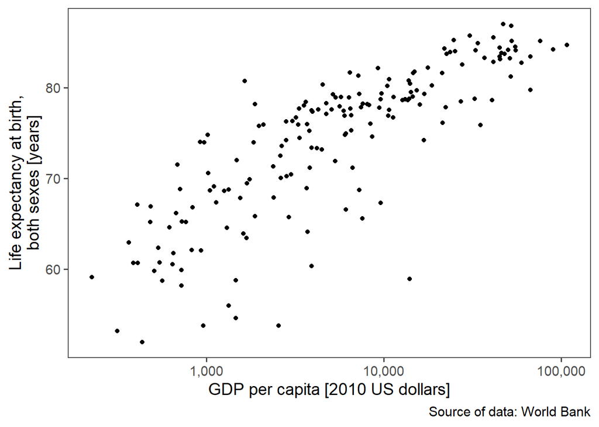

```r
# set the theme for all the plots
theme_set(ggthemes::theme_few(base_size = 14))

qog %>%
  ggplot() +
    aes(x = wdi_gdpcapcon2010,
        y = wdi_lifexpf,
        label = cname) +
    geom_point() +
    scale_x_log10(label = scales::comma) +
    labs(x = "GDP per capita [2010 US dollars]",
         y = "Life expectancy at birth,\nboth sexes [years]",
         caption = "Source of data: World Bank")
```

Life expectancy is influenced by a variety of other factors apart from income. For instance, we can separate the data based on whether the country has a tropical climate:

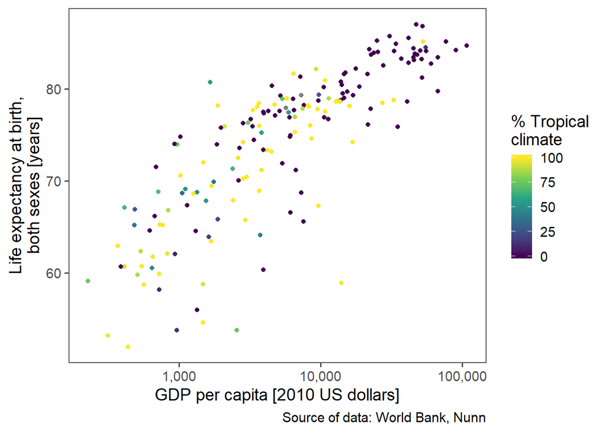

```r
qog %>%
  ggplot() +
    aes(x = wdi_gdpcapcon2010,
        y = wdi_lifexpf,
        label = cname,
        color = nunn_tropical) +
    geom_point() +
    scale_x_log10(label = scales::comma) +
    scale_color_viridis_c() +
    labs(x = "GDP per capita [2010 US dollars]",
         y = "Life expectancy at birth,\nboth sexes [years]",
         color = "% Tropical\nclimate",
         caption = "Source of data: World Bank, Nunn")
```

## 2.1 Facetting based on one variable

But instead of using colors, we could use faceting:

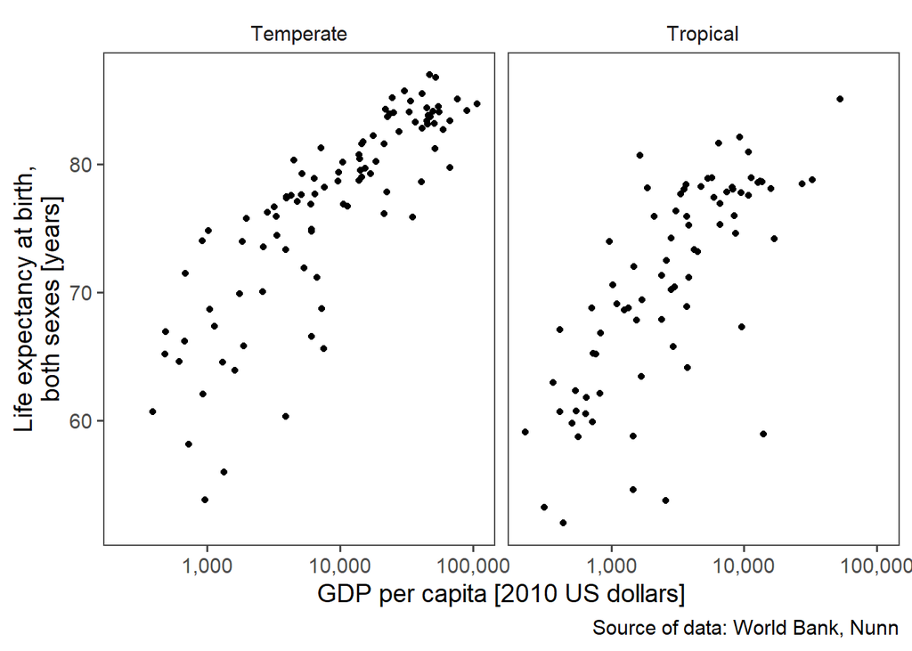

```r
qog %>%
  mutate(tropical = ifelse(nunn_tropical < mean(nunn_tropical, na.rm = TRUE),
                           "Temperate", "Tropical")) %>%
  drop_na(tropical) %>%

  ggplot() +
    aes(x = wdi_gdpcapcon2010,
        y = wdi_lifexpf,
        label = cname) +
    geom_point() +
    scale_x_log10(label = scales::comma) +
    labs(x = "GDP per capita [2010 US dollars]",
         y = "Life expectancy at birth,\nboth sexes [years]",
         caption = "Source of data: World Bank, Nunn") +
    facet_wrap(~tropical)
```

We see that the positive relation between income and life expectancy occurs in both categories. In other words, it is not an artifact of the fact that tropical countries happen to be poorer on average.

I’ve done two things in the code above:

1. I created a binary variable called `tropical` out of the continuous variable `nunn_tropical`, using `mutate()` and the function `ifelse()`. Notice that I haven’t stored this variable in the `qog` dataset, but I’ve only created it temporarily for the purpose of this plot. Also notice the use of `drop_na(tropical)`. This is so we don’t get an extra sub-plot for the cases with missing data. (You can acheive a similar result adding the `drop = TRUE` option inside the facet function.)
2. I used `facet_wrap(~tropical)` to tell `ggplot` to create several plots, one for each value of variable `tropical` (in this case, there are only 2). The instructions about what to plot (in this case, the scatter plot between income and life expectancy) are applied within each of these sub-plots. Each sub-plot contains only a sub-set of the data, conditional on the different values of variable `tropical`. Notice the syntax, in particular the use of the tilde (`~`).

## 2.2 Facetting based on two variables

Suppose that I want to create a facet based on *both* how tropical the country is *and* based on some other variable, e.g. the level of democracy. The healthcare system is influenced to some extent by the government policies, and maybe a more responsive democratic government will provide better healthcare, which, in turn, might have an impact on life expectancy. In many countries, low life expectancy is due to child mortality and contagious diseases – which are affected by government actions. I’m using here Freedom House’s index to assess the level of democracy.

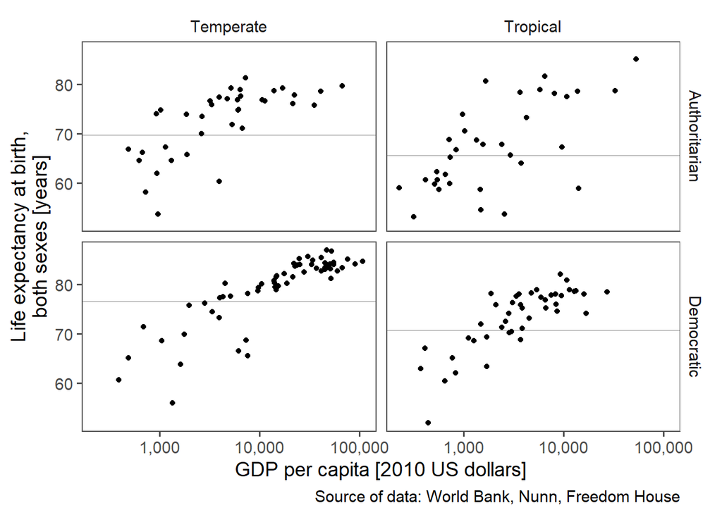

```r
qog %>%
  mutate(tropical = ifelse(nunn_tropical < mean(nunn_tropical, na.rm = TRUE),
                           "Temperate", "Tropical")) %>%
  mutate(democracy = ifelse(fh_ipolity2 < mean(fh_ipolity2, na.rm = TRUE),
                           "Authoritarian", "Democratic")) %>%
  drop_na(tropical, democracy) %>%
  group_by(tropical, democracy) %>%
    mutate(mean_lifexp = mean(wdi_lifexp, na.rm = TRUE)) %>%

  ggplot() +
    aes(x = wdi_gdpcapcon2010,
        y = wdi_lifexpf,
        label = cname) +
    geom_hline(aes(yintercept = mean_lifexp), color = "gray") +
    geom_point() +
    scale_x_log10(label = scales::comma) +
    labs(x = "GDP per capita [2010 US dollars]",
         y = "Life expectancy at birth,\nboth sexes [years]",
         caption = "Source of data: World Bank, Nunn, Freedom House") +
    facet_grid(democracy ~ tropical)
```

I’ve done several things here:

1. Defined another binary variable `democracy` in the same way as I’ve created the `tropical` variable.
2. Used `facet_grid(democracy ~ tropical)` instead of the previous `facet_wrap(~tropical)`. This is what created the grid based on two conditions. If I had used `facet_grid(tropical ~ democracy)` the grid would’ve been arranged with Democracy/Autocracy as columns and Tropical/Temperate as rows.
3. Before calling `ggplot`, I’ve calculated the mean life expectancy for each category using `group_by(tropical, democracy)` and `mutate(mean_lifexp = ...)`. These means are then drawn with the `geom_hline()`. Notice that I put the `geom_hline()` before the `geom_point()`, such that the points are on top.

You can observe that, indeed, the mean life expectancy is lower for both tropical climates and authoritarian regimes. Moreover, the relationship between income and life expectancy persists in all categories, although it is weakest in the authoritarian tropical countries.

# 3 Ploting multiple variables

The sub-plots using the basic faceting option described above use *the same variables*. What if instead of plotting `x` vs `y` for different categories defined by `z`, you want to plot `y` vs `x1`, `y` vs `x2`, …, `y` vs `xn` (or the other way around, `x` vs `y1`, `y2`, …, `yn`)?

We can do this very easily by first reshaping the dataset from its *wide* format to a *long* format, and then using regular faceting on this long format dataset.

The wide format has each variable on its own column, and each row is an observation. Something like this:

| y | A | B | C |
| --- | --- | --- | --- |
| y1 | a1 | b1 | c1 |
| y2 | a1 | b1 | c1 |
| … | … | … | … |
| ym | am | bm | cm |

We can use the function `gather(key = "variable", value = "val", -y)` to transform it into a long format, which looks like the table below, while keeping the variable `y` out of it (if you want keep out of the gathering process more than one variable use `-c(x, y, ...)`):

| y | variable | val |
| --- | --- | --- |
| y1 | A | a1 |
| y2 | A | a2 |
| … | … | … |
| ym | A | am |
| y1 | B | b1 |
| y2 | B | b2 |
| … | … | … |
| ym | B | bm |
| y1 | C | c1 |
| y2 | C | c2 |
| … | .. | … |
| ym | C | cm |

Here’s an example:

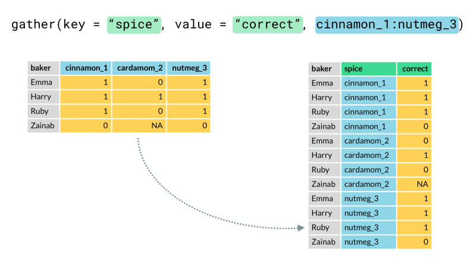

Gif by Alison Presmanes Hill

[A somewhat more intuitive and feature-rich version of `gather` will soon be available: `pivot_longer(names_to = "variable", values_to = "val")`. See [this link](https://tidyr.tidyverse.org/dev/articles/pivot.html). But the `gather` function will continue to work indefinitely.]

Once we’ve gathered the data into the long format, we can use `val` as the variable that changes from one sub-plot to another, and facet on `variable`. Here’s an example:

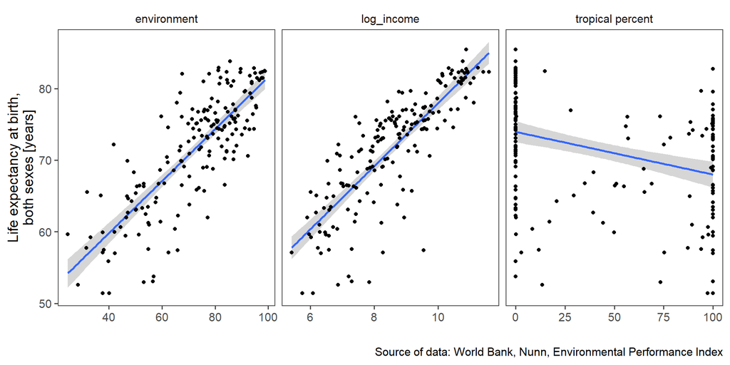

```r
qog %>%
  mutate(log_income = log(wdi_gdpcapcon2010)) %>%
  select(wdi_lifexp,
         log_income,
         `tropical percent` = nunn_tropical,
         environment = epi_eh) %>%
  gather(key = "variable", value = "val", -wdi_lifexp) %>%

  ggplot() +
    aes(x = val, y = wdi_lifexp) +
    geom_smooth(method = "lm") +
    geom_point() +
    facet_wrap(~variable, scales = "free_x") +
    labs(x = "",
         y = "Life expectancy at birth,\nboth sexes [years]",
         caption = "Source of data: World Bank, Nunn, Environmental Performance Index")
```

I only selected three variables to plot here, but you could easily select many more. The only difference would be that the `select` condition coming before `gather` would contain a lot more variables. The `ggplot` code itself will remain unchanged no matter how many variables you add. Several things to note here:

1. If you want to do some change to the variable, like I changed the income to log_income, you need to do it with a `mutate` function *before* the select. You cannot write something like `select(log_income = log(wdi_gdpcapcon2010))`.
2. You can use the `select` function to also change the names of the variables. These names will appear as labels above the facets, so it’s a good idea to change them to something easy to understand. If you want to include spaces in the variable name you can, by enclosing the variable name between back ticks `variable name with spaces in it`. Considering that `gather` will pick up all those variable names for you, this is the one place where it doesn’t matter if you have names with spaces in them (generally speaking, it is frowned upon to have such variable names).

Here’s another example, but using `facet_grid()`:

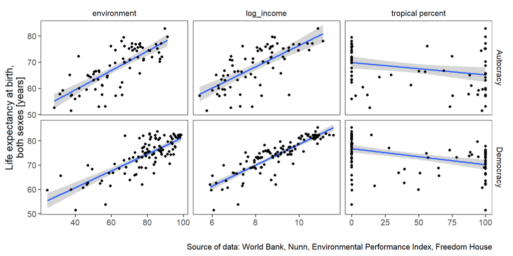

```r
qog %>%
  mutate(log_income = log(wdi_gdpcapcon2010)) %>%
  mutate(democracy = ifelse(fh_ipolity2 < mean(fh_ipolity2, na.rm = TRUE),
                              "Autocracy", "Democracy")) %>%
  select(wdi_lifexp, log_income, democracy,
         environment = epi_eh,
         `tropical percent` = nunn_tropical) %>%
  gather(key = "variable", value = "val", -c(wdi_lifexp, democracy)) %>%

  ggplot() +
    aes(x = val, y = wdi_lifexp) +
    geom_smooth(method = "lm") +
    geom_point() +
    facet_grid(democracy ~ variable, scales = "free") +
    labs(x = "",
         y = "Life expectancy at birth,\nboth sexes [years]",
         caption = "Source of data: World Bank, Nunn, Environmental Performance Index, Freedom House")
```

Notice that I had to keep out of the gathering process both the `y` variable (life expectancy) and the additional faceting variable (`democracy`).

# 4 Ploting multiple pairs of variables

The above trick is extremely useful, and you rarely need anything beyond it – as you usually want to see how *a given variable* is related to many others, rather than see the relationships between many different random pairs of variables.

Nonetheless, sometimes you might need to plot numerous *pairs* of *different* variables. Instead of pairs like `{x1, y}`, `{x2, y}`, …, `{xn, y}`, like above, you might need to plot pairs like `{x1, y1}`, `{x2, y2}`, …, `{xn, yn}`. The `gather` trick doesn’t help you here. In principle you would need a nested gather.

## 4.1 Setting up the control table manually

Fortunately, there’s an easier way using the function `df %>% cdata::rowrecs_to_blocks(vars)`. Pretty much the most complicated thing about using this is remembering its name! The dataframe `df` is your wide format dataset. In our example, it’s the `qog` dataset. The `vars` dataset specifies all the pairs that you want. It has three columns and looks something like this:

| id | x | y |
| --- | --- | --- |
| “pair 1: A vs B” | “A” | “B” |
| “pair 2: B vs C” | “B” | “C” |
| “pair 3: D vs E” | “D” | “E” |
| “pair 4: F vs B” | “F” | “B” |
| “pair 5: B vs A” | “B” | “A” |

The column names (`id`, `x`, `y`) could be anything you want, but note that all values in this dataframe need to be strings. The values of the `id` can also be anything you want, as long as they are unique. These labels under `id` will appear as the labels of each sub-plot (we’re going to facet by `id`), so you want to make them descriptive. The columns `x` and `y` contain the names of the variables from the `df` dataframe that are going to be paired together in each sub-plot. This `vars` dataframe is thus a quick way of setting up the list of all the plots you want to make and the labels for each plot. In the terminology of the `cdata` package, the `vars` dataframe is called the “control table”.

The function `cdata::rowrecs_to_blocks(df, vars)` will generate the long format dataframe of the *pairs*. This is just like `gather` but with two variables instead of just one. Unlike `gather`, you don’t need to bother with the `select` before calling it, because it automatically transforms into long format *only* the variables specified in the control table.

If you want to bring in some additional variables from `df`, without getting them mixed up in this transformation to the long format, you can add the option `columnsToCopy = c("P", "Q", "R", ...)` and variables “P”, “Q”, “R”, etc. will be copied separately as they are. This is similar to using `-c(P, Q, R, ...)` in `gather()`.

Here’s an example:

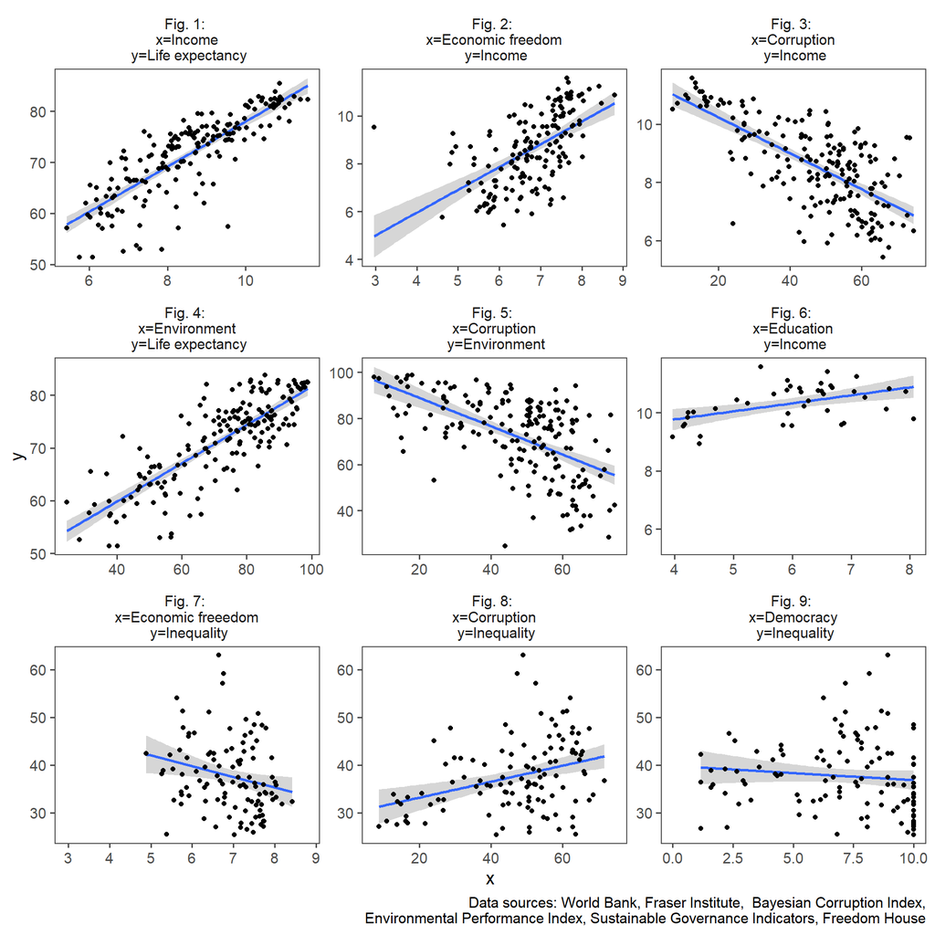

```r
vars <- tribble(
  ~id,                                              ~x,                  ~y,
  "Fig. 1: \n x=Income \n y=Life expectancy",       "log_income", "wdi_lifexp",
  "Fig. 2: \n x=Economic freedom \n y=Income",      "fi_index",   "log_income",
  "Fig. 3: \n x=Corruption \n y=Income",            "bci_bci",    "log_income",
  "Fig. 4: \n x=Environment \n y=Life expectancy",  "epi_eh",     "wdi_lifexp",
  "Fig. 5: \n x=Corruption \n y=Environment",       "bci_bci",    "epi_eh",
  "Fig. 6: \n x=Education \n y=Income",             "sgi_soed",   "log_income",
  "Fig. 7: \n x=Economic freeedom \n y=Inequality", "fi_index",   "wdi_gini",
  "Fig. 8: \n x=Corruption \n y=Inequality",        "bci_bci",    "wdi_gini",
  "Fig. 9: \n x=Democracy \n y=Inequality",         "fh_ipolity2", "wdi_gini"
  )

qog %>%
  mutate(log_income = log(wdi_gdpcapcon2010)) %>%
  cdata::rowrecs_to_blocks(vars) %>%

  ggplot() +
    aes(x = x, y = y) +
    geom_smooth(method = "lm") +
    geom_point() +
    facet_wrap(~id, scales = "free") +
    labs(caption = "Data sources: World Bank, Fraser Institute,  Bayesian Corruption Index,\n Environmental Performance Index, Sustainable Governance Indicators, Freedom House")
```

One thing to notice here is that you can make a label span over several rows by using the `\n` code. I’ve used this several times above.

When you do this kind of thing in a rmarkdown document, you will need to specify the chunk options, `fig.height` and `fig.width`. For instance, the chuck above has the options: `{r, fig.height=10, fig.width=10}`. Obviously, the more such plots you are generating, the greater the height of the produced figure should be. Similarly, if you’re using `ggsave()` to save the plot in a file, make sure the size of the image is large enough (using the `height` and `width` options of `ggsave`).

How do you create the control table manually?

1. You can write it down inside a `tribble()` function (as I’ve done above). This allows you to write it row-by-row, rather than column-by-column (as in a `data.frame()`). Notice that the variable names in the first row are preceded by a tilde.
2. Even better, you can create the table in Excel or Google Sheets and than just copy-paste it into your R code with the [`datapasta` add-on](https://cran.r-project.org/web/packages/datapasta/README.html).
3. Or you can just have the control table stored in a file, and import it with `rio::import()`.

## 4.2 Setting up the control table programatically

You can use this trick for generating a large number of plots with a single `ggplot()` call even when the set of pairs of variables is generated by some automated process – rather than defined manually like above.

For example, suppose that I want to find the most highly correlated variables in the `qog` dataset, and plot their scatter plots.

First, build the correlation matrix, and flatten it into a long-format table. We’re going to create the control table by simply taking a subset of this correlations dataframe.

```r
qog_cor <- qog %>%
  select_if(is.numeric) %>%

  # creates matrix of all corrlations
  cor(use="pairwise.complete.obs") %>%
  as.data.frame() %>%
  rownames_to_column("v1") %>%

  # turn it into long format
  gather(key = "v2", value = "correlation", -v1) %>%

  # eliminate correlations to self
  filter(correlation != 1)
```

Second, take a sample out of the set of highly correlated pairs, and plot them using the same procedure as before:

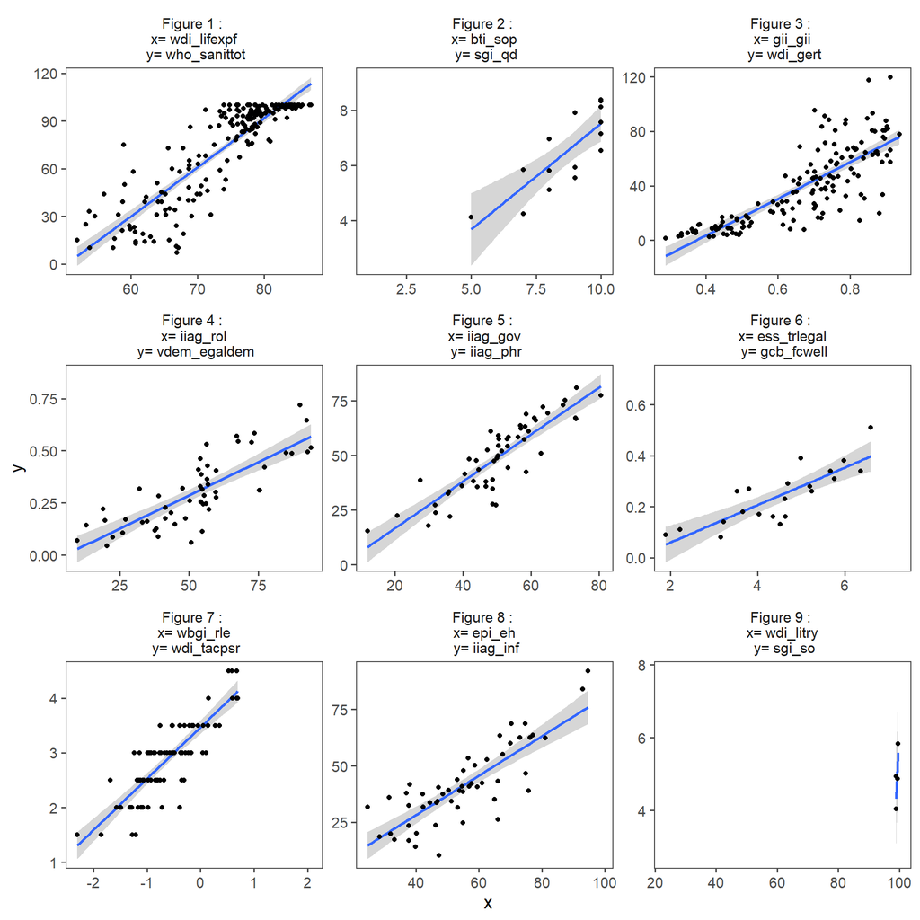

```r
vars_highcor <- qog_cor %>%

  # select highly correlated
  filter(correlation > 0.8) %>%

  # select a random sample of 9 pairs
  sample_n(size = 9, replace = TRUE) %>%

  # build the control table
  rownames_to_column("id") %>%
  select(id, v1, v2) %>%
  mutate(id = paste("Figure", id, ": \n x=", v1, "\n y=", v2))


qog %>% cdata::rowrecs_to_blocks(vars_highcor) %>%
  ggplot() +
    aes(x = v1, y = v2) +
    geom_smooth(method = "lm") +
    geom_point() +
    facet_wrap(~id, scales = "free") +
    labs(x = "x", y = "y")
```

To see the meaning of these variables, you need to either check the [codebook from the *Quality of Government Institute*](https://qog.pol.gu.se/data/datadownloads/qogbasicdata), or search for the variables in the summary table at the beginning of this document and see their description. You can try to improve the plot by defining the `id` variable using the variable labels instead of their names.

Here’s also a sample of the highly anti-correlated, and now using `facet_grid()`:

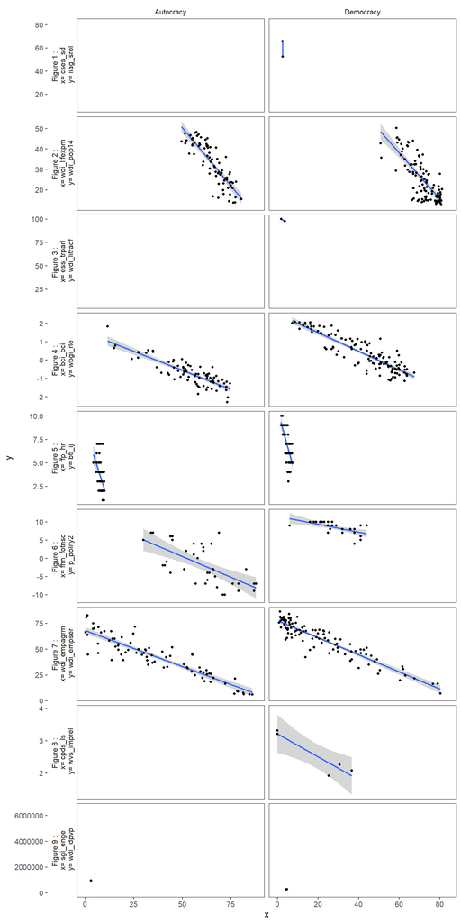

```r
vars_anticor <- qog_cor %>%

  # select highly anti-correlated
  filter(correlation < -0.8) %>%

  # select a random sample of 9 pairs
  sample_n(size = 9, replace = TRUE) %>%

  # build the control table
  rownames_to_column("id") %>%
  select(id, v1, v2) %>%
  mutate(id = paste("Figure", id, ": \n x=", v1, "\n y=", v2))


qog %>%
  mutate(democracy = ifelse(fh_ipolity2 < mean(fh_ipolity2, na.rm = TRUE),
                              "Autocracy", "Democracy")) %>%
  cdata::rowrecs_to_blocks(vars_anticor, columnsToCopy = c("democracy")) %>%

  ggplot() +
    aes(x = v1, y = v2) +
    geom_smooth(method = "lm") +
    geom_point() +
    facet_grid(id ~ democracy, scales = "free", switch = "y") +
    labs(x = "x", y = "y")
```

# 5 Combining plots in general

Apart from faceting, the most general, and least concise, way of combining many ggplots into one is by using the `gridExtra::grid.arrange` or the [`patchwork` package](https://github.com/thomasp85/patchwork). Under this approach you will create several different ggplot objects separately and then put them all together:

```r
p1 <- df1 %>% ggplot() + ...
p2 <- df2 %>% ggplot() + ...
p3 <- df3 %>% ggplot() + ...

# using grid.arrange
gridExtra::grid.arrange(p1, p2, p3, ...)

# using patchwork
# (p1 and p2 are on first row, and p3 occupies the entire second row):
(p1 + p2) / p3
```

`patchwork` is by far the easiest to use but it’s not yet on CRAN, so you’d have to install it from github.